# July 7th

Today's Goal: Do testing both supervised and unsupervised methods. Continue to try to optimize unsupervised to detect REM better.

First, I'll try unsupervised spectral clustering on subject 1032 to see if it works better. To seperate Wake/Sleep, I will use EMG Power, 0.5-55 Hz/0.5-22 Hz EEG Power Ratio, and number of sign inversions.

```python
%matplotlib inline
import numpy as np
import matplotlib as plt
import load,processing,clustering,plotting
from importlib import reload
eeg,emg,actual=load.getData('../Data/channels1032.dat','../Data/teststates1032.dat')
features=processing.getFeatures(eeg,emg)
```

```
Reading Channels from file...
Done!
Reading test states from file...
Done!
```

```
Done!
Normalizing features...
Done!
```

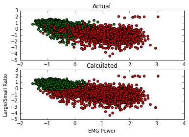

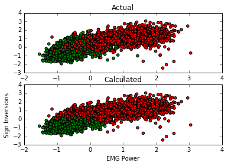

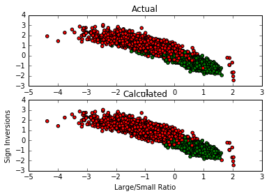

```
Done!
```

```python
reload(plotting)
from sklearn.cluster import SpectralClustering
wakeFeatures=features[:,3:]
actualWake=[0 if state==0 else 1 for state in actual]
clusters=SpectralClustering(n_clusters=2)
wakeLabels=clusters.fit_predict(wakeFeatures)
plotting.plotFeatures(wakeFeatures,wakeLabels,actualWake,['EMG Power','Large/Small Ratio','Sign Inversions'])
```

This looks more decent. Let's see exactly how many of the states were correct.

```python
matches=0
for i in range(len(actualWake)):
    state1,state2=actualWake[i],wakeLabels[i]
    if state1==state2:
        matches+=1
print("Percent similarity between calculated and actual wake/sleep states: "+str(matches/len(actualWake)))
print()
clustering.printSimilarity(actualWake,wakeLabels)
```

```
Percent similarity between calculated and actual wake/sleep states: 0.9157201272149024

Wake. Calculated 1989 with actual 1792
NREM. Calculated 2413 with actual 2610
REM. Calculated 0 with actual 0
```

Now let's see the performance in detecting REM sleep. Features used will be: Delta, Delta/Theta Ratio, and EMG Median

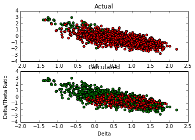

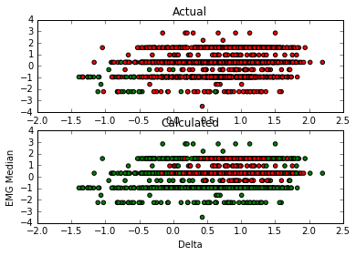

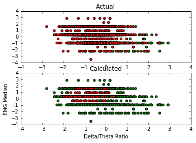

```
Done!
```

```python
sleepIndices=[i for i in range(len(wakeLabels)) if wakeLabels[i]==1]
#REM=1, NREM=0
actualREM=[1 if actual[i]==2 else 0 for i in sleepIndices]
remFeatures=[]
for i in sleepIndices:
    remFeatures.append(features[i,:3])
remFeatures=np.asarray(remFeatures)
clusters=SpectralClustering(n_clusters=2)
remLabels=clusters.fit_predict(remFeatures)
plotting.plotFeatures(remFeatures,remLabels,actualREM,['Delta','Delta/Theta Ratio','EMG Median'])
```

This doesn't look as good, but let's see the whole thing done in ensemble.

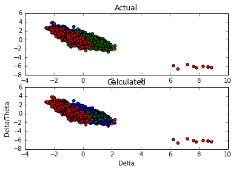

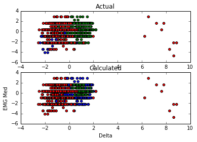

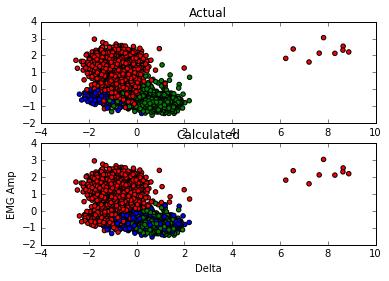

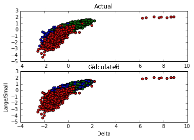

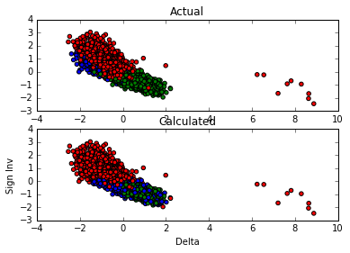

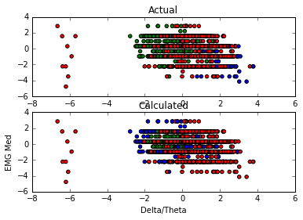

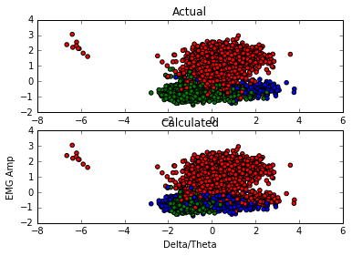

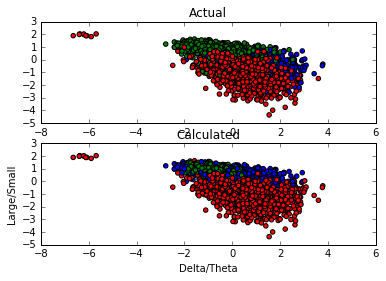

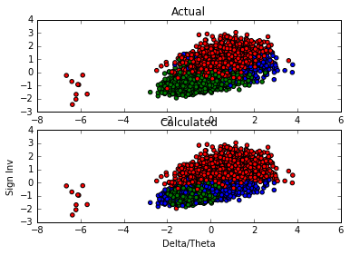

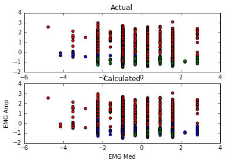

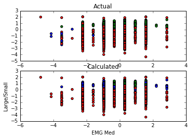

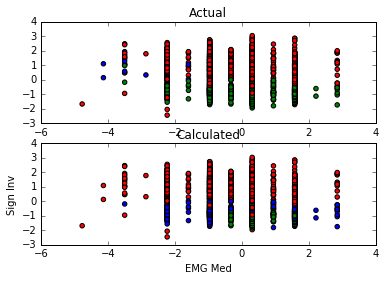

[3 more figures not shown]

```
Done!
```

```python
reload(clustering)
labels=clustering.doubleSpectralCluster(features)
plotting.plotFeatures(features,labels,actual,['Delta','Delta/Theta','EMG Med','EMG Amp','Large/Small','Sign Inv'])
```

```python
matches=0
for i in range(len(actual)):
    state1,state2=labels[i],actual[i]
    if state1==state2:
        matches+=1
print("Percent similarity between calculated and actual wake/sleep states: "+str(matches/len(actual)))
print()
clustering.printSimilarity(actual,labels)

remmatches=0
rem=0
for i in range(len(actual)):
    state1,state2=labels[i],actual[i]
    if state2==2:
        rem+=1
        if state1==state2:
            remmatches+=1
print("Percent similarity between calculated and actual rem states: "+str(remmatches/rem))
```

```
Percent similarity between calculated and actual wake/sleep states: 0.7244434348023625

Wake. Calculated 1989 with actual 1792
NREM. Calculated 1437 with actual 2382
REM. Calculated 976 with actual 228
Percent similarity between calculated and actual rem states: 0.2850877192982456
```

This does not hit as many rem states as kmeans, so spectral clustering did not work out as well. For now, I will start crossvalidating supervised to see how well that does.

```python
from sklearn.cross_validation import KFold
from sklearn import svm,tree
from sklearn.naive_bayes import GaussianNB
from sklearn.neighbors import KNeighborsClassifier
import time
reload(processing)
def supervisedCrossValidate(subjectnum):
    eeg,emg,actual=load.getData('../Data/channels{}.dat'.format(subjectnum),'../Data/teststates{}.dat'.format(subjectnum))
    features=processing.getFeatures(eeg,emg)
    features=np.asarray(features)
    actual=np.asarray(actual)

    clfsvm=svm.SVC(kernel='linear')
    clftree=tree.DecisionTreeClassifier(criterion='entropy',max_depth=4)
    clfnb=GaussianNB()
    clfknn=KNeighborsClassifier()
    print("Subject {}, Mean Classifier Accuracy, Mean REM Sensitivity, Mean REM Specificity, Mean NREM Sensitivity, Mean NREM Specificity".format(subjectnum))
    classifiers=[clfsvm,clftree,clfnb,clfknn]
    clfTime=[]
    for clf in classifiers:
        scores=[]
        sensitivitiesrem=[]
        specificitiesrem=[]
        sensitivitiesnrem=[]
        specificitiesnrem=[]
        print(clf.__class__.__name__,end=',')
        ctime=0
        kf=KFold(len(features),n_folds=4)
        for trainIndex,testIndex in kf:
            features_train,features_test=features[trainIndex],features[testIndex]
            labels_train,labels_test=actual[trainIndex],actual[testIndex]

            begin=time.time()
            clf.fit(features_train,labels_train)
            ctime+=time.time()-begin

            scores.append(clf.score(features_test,labels_test))
            calculatedLabels=clf.predict(features_test)

            remtp,remfp,remtn,remfn=0,0,0,0
            nremtp,nremfp,nremtn,nremfn=0,0,0,0

            for i in range(len(calculatedLabels)):
                if labels_test[i]==2:
                    if calculatedLabels[i]==2:
                        remtp+=1
                    else:
                        remfn+=1
                else:
                    if calculatedLabels[i]==2:
                        remfp+=1
                    else:
                        remtn+=1

                if labels_test[i]==1:
                    if calculatedLabels[i]==1:
                        nremtp+=1
                    else:
                        nremfn+=1
                else:
                    if calculatedLabels[i]==1:
                        nremfp+=1
                    else:
                        nremtn+=1

            sensitivitiesrem.append(float(remtp)/(remtp+remfn))
            specificitiesrem.append(float(remtn)/(remtn+remfp))

            sensitivitiesnrem.append(float(nremtp)/(nremtp+nremfn))
            specificitiesnrem.append(float(nremtn)/(nremtn+nremfp))

        print((np.mean(scores)),end=',')
        print((np.mean(sensitivitiesrem)),end=',')
        print((np.mean(specificitiesrem)),end=',')
        print((np.mean(sensitivitiesnrem)),end=',')
        print((np.mean(specificitiesnrem)),end='')
        print()
        clfTime.append(ctime)

    print("-----------------")
    print("Classifier Time Array: ")
    print(clfTime)
    print("-----------------")


supervisedCrossValidate(1032)
supervisedCrossValidate(1039)
supervisedCrossValidate(1040)
supervisedCrossValidate(1134)
supervisedCrossValidate(1139)
supervisedCrossValidate(1140)
```

```
Reading Channels from file...
Done!
Reading test states from file...
Done!
```

```
Done!
Normalizing features...
Done!
Subject 1032, Mean Classifier Accuracy, Mean REM Sensitivity, Mean REM Specificity, Mean NREM Sensitivity, Mean NREM Specificity
SVC,0.934802039468,0.762238741651,0.99157678442,0.959080988465,0.919658404
DecisionTreeClassifier,0.922309677153,0.664326115061,0.986003734817,0.937761947287,0.938103701624
GaussianNB,0.933666295104,0.784370286576,0.980371851187,0.942487936373,0.947229002872
KNeighborsClassifier,0.931623524069,0.727359405301,0.991090288844,0.950107113376,0.926895793236
-----------------
Classifier Time Array:
[0.2324213981628418, 0.036496639251708984, 0.004263162612915039, 0.008218765258789062]
-----------------
Reading Channels from file...
Done!
Reading test states from file...
Done!
Done!
Normalizing features...
Done!
Subject 1039, Mean Classifier Accuracy, Mean REM Sensitivity, Mean REM Specificity, Mean NREM Sensitivity, Mean NREM Specificity
SVC,0.942291311755,0.823505140693,0.993579731306,0.964974264589,0.940089022799
DecisionTreeClassifier,0.932069846678,0.831392045455,0.987599887018,0.9516365542,0.938130084332
GaussianNB,0.922913117547,0.926959325397,0.965975193007,0.961712363069,0.941307759869
KNeighborsClassifier,0.939522998296,0.786215954185,0.992463823773,0.95955653086,0.943793845435
-----------------
Classifier Time Array:
[0.22266769409179688, 0.04226279258728027, 0.0041387081146240234, 0.008819818496704102]
-----------------
Reading Channels from file...
Done!
Reading test states from file...
Done!
Done!
Normalizing features...
Done!
Subject 1040, Mean Classifier Accuracy, Mean REM Sensitivity, Mean REM Specificity, Mean NREM Sensitivity, Mean NREM Specificity
SVC,0.872444633731,0.748713177067,0.990642465737,0.925330868469,0.849485917621
DecisionTreeClassifier,0.856473594549,0.69282216767,0.989533813609,0.893119884204,0.853741518164
GaussianNB,0.836882453152,0.822335946574,0.956548498682,0.936753526305,0.820295390573
KNeighborsClassifier,0.854557069847,0.739088401436,0.988838440141,0.891516457557,0.853211712657
```

[output cut: 37 more lines]

```
Done!
Reading test states from file...
Done!
Done!
Normalizing features...
Done!
Subject 1140, Mean Classifier Accuracy, Mean REM Sensitivity, Mean REM Specificity, Mean NREM Sensitivity, Mean NREM Specificity
SVC,0.907239819005,0.739117503259,0.993361460387,0.935558321332,0.913108534242
DecisionTreeClassifier,0.895701357466,0.793324234029,0.986403743725,0.932425825936,0.903603082564
GaussianNB,0.90520361991,0.718262100717,0.992872394169,0.944315843616,0.905618984398
KNeighborsClassifier,0.897737556561,0.685931388527,0.993127866565,0.920070461734,0.90988960825
-----------------
Classifier Time Array:
[0.29576611518859863, 0.03807520866394043, 0.003887176513671875, 0.009382009506225586]
-----------------
```

These are the statistics for Classifier Accuracy, REM Specificity/Sensitivity, and NREM Specificity/Sensitivity in CSV format, along with arrays of how long each classifier took (in order: SVM, Decision Tree, Naive Bayes, K Nearest Neighbors). Below is the graphical representation:

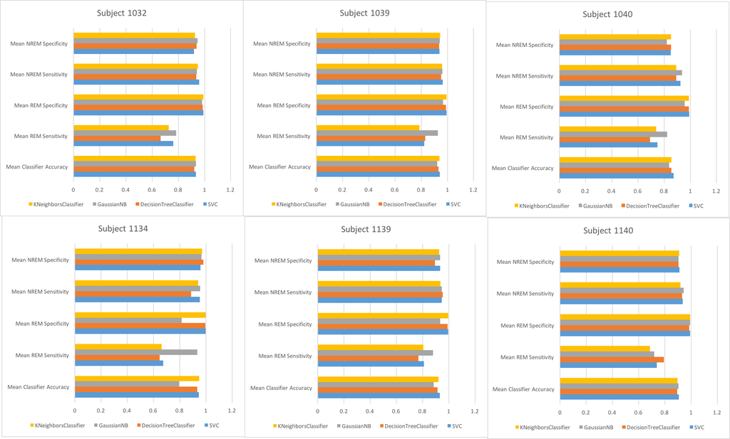

```python
from IPython.display import Image
Image(filename='../FourFoldCrossValidationResults.png')
```

I also need to focus on computation time, so I will find out which feature takes the longest to calculate.

```python
reload(processing)
results=[0,0,0,0,0,0]
for i in range(len(eeg)):
    e1,e2=eeg[i],emg[i]
    a=processing.timeFeatures(e1,e2)
    for i in range(len(results)):
        results[i]+=a[i]
print("Delta Power","Delta/Theta Power Ratio","Sign Inversions","EMG Power","EMG Median","Large Ratio")
print(results)
```

```
Delta Power Delta/Theta Power Ratio Sign Inversions EMG Power EMG Median Large Ratio
[2.347835063934326, 4.670789003372192, 2.3839712142944336, 2.3483595848083496, 0.2884342670440674, 4.72378396987915]
```

None of the results take too long, considering the real-time version will only be calculating one epoch at a time, so it is probably best to use these features for now. Autocorrelation, however, will be thrown out since it has a very low F value in differentiating REM and takes a lot of computation.

In terms of clasifiers, Naive Bayes definetely takes the least amount of time. However, the classifiers take so little time that it may not matter all too much. Now, I will look into possibly using ensemble methods before fully transitioning into converting this into real-time.